# VascularTrees.jl

Pharmacokinetic simulations on synthetic liver vascular trees

Mariia Myshkina, Matthias König

2026-11-26

## Contents

**Overview**

- Liver vascularization as coupled trees
- Pipeline

**Step 1 — `build_arrow_graphs.jl`**

- Overview: 1a and 1b
- 1a · Tree → ODE table · added edges · `<tree>.arrow`
- 1b · Terminal nodes · matching · `T.arrow`

**Step 2 — `run_simulations.jl`**

- Overview: 2a, 2b, 2c
- 2a · Setup · matrices: tree · matrices: terminal part
- 2b · Pharmacokinetic model
- 2c · Coupling in time · diagram · `simulations/*.arrow`

**Step 3 — `create_vtk.jl`**

- 3 · From numbers to an animation

**Simulation results**

- 10² · 10⁴ · 10⁵ · 10⁶ terminal nodes

**Code and performance**

- Software design · Benchmark · Next steps

## Liver vascularization as coupled trees

| Configuration | Inflow trees | Outflow trees |
| --- | --- | --- |
| `Rectangle_trio` | A, P | V |
| `Rectangle_quad` | A, P | V, B |

## Pipeline: independent steps

[figure not shown]

# Step 1 — `build_arrow_graphs.jl`

## Step 1 at a glance

1a **Individual trees**

`process_julia_graph`

`julia/<tree>.lg`, `_edges.csv`, `_nodes.csv`  
→ `graphs/<tree>.arrow`

- runs **for every tree separately** — A, P, V, B do not know each other
- turns a generated tree into an **ODE-ready table**: one row per edge, added edges, ODE groups, neighbours, direction of blood flow

→

1b **Terminal nodes**

`process_terminal_nodes`

all `graphs/<tree>.arrow`  
→ `graphs/T.arrow`

- the **only place where the trees meet**
- matches the leaves of the trees by position and builds the sinusoid compartments $T_k$ that couple them

1a must run before 1b — 1b reads the tables written by 1a

## 1a · From a generated tree to an ODE table

What do we have?

- `.lg`: edge list `(source, target)` — only the skeleton
- `_nodes.csv`: coordinates; **attributes stored on nodes** — a node describes the edge *arriving* at it
- every tree read from root to leaves, also **outflow trees** (V, B) — against the blood flow
- units mm³, s

→

How do we get there?

1. **join** skeleton + attributes on `target_id`, convert to L, L/min; $V = \pi r^2 l$
2. **label** edges: *preterminal* (target is never a source), *start* (source is never a target)
3. **add edges**: a self-loop $(n,n)$ per leaf = terminal compartment; $(0,\text{root})$ = marginal (dose)
4. **ODE group** per edge (0 marginal, 1 inner, 2 preterminal, 3 terminal)
5. **reverse** outflow trees
6. **predecessors / successors** of every edge
7. save `graphs/<tree>.arrow`

→

What do we need?

- **one ODE species per edge** (concentration in that vessel segment)
- for every edge: flow $Q$, volume $V$, **where it gets blood from, where it sends it**
- edges **in the direction of blood flow**
- an entry point for the **dose**
- an exit point at every leaf, to connect to the **sinusoids**
- which **equation** each edge needs

## 1a · Which edges are added to a tree

[figure not shown]

- **We work with edges, not with nodes:** one ODE species = one vessel segment (edge). A node has no volume, so the place where the dose enters and the terminal compartment at a leaf need **their own edges** — the marginal edge $(0, \text{root})$ and the self-loops $(n, n)$
- **The trees stay independent:** every tree is processed alone and has its own table; they are connected only later, through `T.arrow` (1b)
- inflow tree shown; for outflow trees the arrows are reversed (leaves → root → 0)

## 1a · `graphs/<tree>.arrow` — one row per edge

One row = one edge = one ODE species, in the order used by the solver. Columns that describe the whole tree (id, nodes, special edges) are shorter and padded with `missing`: an Arrow table needs columns of equal length.

| `all_edges` | `species_ids` | `flows` | `volumes` | `ODE_groups` | `predecessors` | `successors` |
| --- | --- | --- | --- | --- | --- | --- |
| (1, 15) | `A_1_15` | 0.096 | 0.00013 | 1 | [39] | [14, 15] |
| (3, 2) | `A_3_2` | 0.00738 | 1.62e-07 | 2 | [14] | [26] |
| (3, 7) | `A_3_7` | 0.0665 | 0.000124 | 1 | [14] | [6, 7] |
| ⋮ | ⋮ | ⋮ | ⋮ | ⋮ | ⋮ | ⋮ |
| (26, 26) | `T_13` | 0 | 7.69e-08 | 3 | [25] | [] |
| (0, 1) | `Marginal` | 0 | 0.00013 | 0 | [] | [1] |

| Columns | Length | Content |
| --- | --- | --- |
| `all_edges`, `species_ids`, `flow_ids`, `volume_ids`, `flows` [L/min], `volumes` [L], `ODE_groups` | one per edge | the edge and its ODE species |
| `predecessors`, `successors` | one list per edge | **row numbers** of the edges before / after it |
| `vascular_tree_id`, `is_inflow` | row 1 | the tree |
| `nodes_ids`, `nodes_coordinates` | one per node | geometry (for 1b and the visualization) |
| `start_edge`, `preterminal_edges`, `terminal_edges` | one per such edge | special edges |

## 1b · Connecting the trees: terminal nodes

What do we have?

- the `.arrow` tables of all trees from 1a
- the same number $N$ of leaves in every tree
- but the trees were **generated independently**: leaf $k$ of A has nothing to do with leaf $k$ of V
- only the **coordinates** of the leaves

→

How do we get there?

- **group the leaves by position**: one leaf per tree per group, leaves of a group close together (next slide)
- the grouping is a **permutation per tree**: reorder flows, species ids, coordinates of every tree with it
- outflow flows of V and B are **summed** per terminal
- save `graphs/T.arrow`: one row per terminal $T_k$ — its inflow species, flows, coordinates

→

What do we need?

- **sinusoid compartments** $T_k$
- each $T_k$ gets blood from **one leaf of every inflow tree** (A, P) and drains into **one leaf of every outflow tree** (V, B)
- for each $T_k$: inflow flows, total outflow flow

## 1b · Matching the leaves of different trees

$$\min_{\text{groups}} \sum_{g=1}^{N} \sum_{t=1}^{m} \lVert p_{t,g} - \mu_g \rVert^2,
\qquad \mu_g = \tfrac{1}{m}\textstyle\sum_t p_{t,g}$$

**1. Greedy start**

- for every leaf of A: its $k$ nearest leaves in the other trees (kd-tree)
- score all combinations, take the best ones, each leaf only once
- pair the leftovers

**2. Alternating improvement**

- fix all trees but one, re-assign that tree’s leaves to the group centroids
- `HungarianAssignment()` — exact
- `AuctionAssignment()` — sparse, $k$ candidates, $k$ adapted per group
- repeat until nothing changes

**Quality check:** lower bound = optimal pairwise matchings (Hungarian), summed, divided by $m$

## 1b · `graphs/T.arrow` — one row per terminal

Row $k$ = terminal $T_k$. Each group of columns `<name>_1, <name>_2, …` is one **block** of the terminal matrices, stored column by column (`species_id_1` = row 1 of the block, …).

| `species_id_1` | `species_id_2` | `species_id_3` | `flow_value_1` | `flow_value_2` | `flow_value_3` | `synch_idx_1` | `synch_idx_2` | `synch_idx_3` | `synch_idx_4` |
| --- | --- | --- | --- | --- | --- | --- | --- | --- | --- |
| `T_1` | `A_9_10` | `P_5_2` | 0.0373 | 0.00738 | 0.0295 | 3 | 1 | 4 | 9 |
| `T_2` | `A_9_6` | `P_7_6` | 0.0373 | 0.00738 | 0.0295 | 2 | 2 | 3 | 2 |
| `T_3` | `A_25_20` | `P_19_20` | 0.0373 | 0.00738 | 0.0295 | 12 | 8 | 12 | 8 |
| ⋮ | ⋮ | ⋮ | ⋮ | ⋮ | ⋮ | ⋮ | ⋮ | ⋮ | ⋮ |
| `T_13` | `A_11_12` | `P_11_12` | 0.0373 | 0.00738 | 0.0295 | 4 | 4 | 5 | 4 |

| Columns | Block rows | Content |
| --- | --- | --- |
| `species_id_*` | $1 + n_\text{in}$ | `T_k`, then the preterminal species of A, P feeding it |
| `flow_id_*`, `flow_value_*` | $1 + n_\text{in}$ | `Outflow` = $Q_V + Q_B$, then $Q_A$, $Q_P$ |
| `coordinates_*`, `affiliation_*` | $n_\text{trees}$ | position of the leaf in A, P, V, B and its tree |
| `synch_idx_*` | $n_\text{trees}$ | **result of the matching**: which preterminal edge of tree A, P, V, B belongs to $T_k$ |
| `volume` | — | $V_T$, the same for all terminals |

# Step 2 — `run_simulations.jl`

## Step 2 at a glance

2a **Setting up**

`run_simulations`

`graphs/*.arrow`  
→ parameters, initial values, matrices

- one ODE problem per subsystem A, P, V, B, T
- synchronization indices from the matching
- sparsity pattern of the Jacobian, solution matrices on disk

→

2b **Model**

`jf_inflow!`, `jf_outflow!`, `jf_terminal!`, `jac!`

state → time derivative

- mass balance per edge with flow $Q$ and volume $V$
- one right-hand side per kind of subsystem
- analytic Jacobian

→

2c **Coupling in time**

`solve_tree!`, `integrate!`

five integrators  
→ `simulations/*.arrow`

- every $dt$: advance each subsystem, **exchange** the shared species, store
- result: concentration over time for every species

## 2a · Setting up the problem

What do we have?

- `graphs/<tree>.arrow`: edges, $Q$, $V$, ODE groups, predecessors / successors
- `graphs/T.arrow`: which preterminal species feed which terminal

→

How do we get there?

- **one ODE problem per subsystem**: A, P, V, B and T — five smaller problems instead of one huge one
- parameters as **flat arrays** (index + offset) → type-stable, fast right-hand side
- **synchronization indices**: which species of a tree touches which $T_k$ (from the matching)
- **analytic sparse Jacobian** → `CVODE_BDF` with the sparse solver `KLU`
- results go to **memory-mapped files** on disk (do not need to fit in RAM); free disk space is checked first

→

What do we need?

- **concentration over time** in every edge of every tree and in every sinusoid
- for a given dose and time span
- for trees with up to $10^6$ leaves — **millions of species**

## 2a · Matrices in `solve_tree!` — one tree

**State `u[tree]`**: a vector, one entry per edge, in the row order of `<tree>.arrow`

| A_1_15 | A_3_2 | A_3_7 | … | T_1 | … | T_13 | Marginal |
| --- | --- | --- | --- | --- | --- | --- | --- |
| inner | preterminal | inner |  | terminal |  | terminal | dose |

**Neighbours** (`VascularTreeParameters`): all lists in one flat vector + offsets

| predecessors_idx | 39 | 14 | 14 | … |  |
| --- | --- | --- | --- | --- | --- |
| predecessors_offset | 1 | 2 | 3 | 4 | … |

predecessors of edge `ke` = `idx[offset[ke] : offset[ke+1]-1]` — no vector of vectors, one loop over contiguous memory

**Jacobian `J[tree]`**: sparse $n \times n$

- `J[ke, ke]` (outflow of the edge) and `J[post, ke]` (what the edge sends to its successors)
- **lower triangular** in flow order; the model is linear → $J$ does not depend on $u$ or $t$
- only its sparsity pattern is allocated once (`jac_prototype`)

**Solution `solutions[tree]`**: $n_\text{species} \times (\text{steps} + 1)$

- column = stored time point (adaptive saving)
- memory-mapped file in `simulations/` → large trees do not need to fit in RAM
- written as `simulations/<tree>_simulations_<dt>_dt.arrow`

## 2a · Matrices in `solve_tree!` — terminal part and coupling

**Terminal state**: block $(1 + n_\text{in}) \times N$, column $k$ = terminal $T_k$

|  | k = 1 | k = 2 |  | k = N |
| --- | --- | --- | --- | --- |
| row 1 | T_1 | T_2 | … | T_N |
| row 2 | A pre. of T_1 | A pre. of T_2 | … | … |
| row 3 | P pre. of T_1 | P pre. of T_2 | … | … |

- `flow_values`: same shape — row 1 = $Q_V + Q_B$, rows 2, 3 = $Q_A$, $Q_P$
- stored as **one vector, column by column** (Sundials’ Jacobian needs a vector): `[T_1, A, P, T_2, A, P, …]` → row $i$ = `u[i : n_rows : end]`

**Synchronization indices** `sidx[tree]` (from `synch_idx_*` in `T.arrow`): positions of the species of a tree that touch the terminals, ordered by $k$

|  | k = 1 | k = 2 |  |
| --- | --- | --- | --- |
| A, P: preterminal | 3 | 2 | … |
| V, B: terminal | 4 | 3 | … |

**Exchange after every step** $dt$:

```julia
# inflow trees → terminal part (row 2, 3)
u_T[2:n_rows:end] .= u_A[sidx_A]
u_T[3:n_rows:end] .= u_P[sidx_P]
# terminal part (row 1) → outflow trees
u_V[sidx_V] .= u_T[1:n_rows:end]
u_B[sidx_B] .= u_T[1:n_rows:end]
```

## 2b · Model: inflow trees (A, P)

One concentration $C_e$ per edge, mass balance with flow $Q$ and volume $V$, $\;\frac{dC_e}{dt} = \frac{1}{V_e}\left(\text{inflow} - \text{outflow}\right)$ — one equation per ODE group:

| group | edge | equation |
| --- | --- | --- |
| **0** marginal | before the root, the dose enters | $C_0(t) = \text{infusion rate}(t) \,/\, Q_{\text{root}}$ — set, not integrated |
| **1** inner | inside the tree | $\dfrac{dC_e}{dt} = \dfrac{1}{V_e}\left(Q_e\,C_{\text{parent}} - \sum_{\text{children}} Q_c\;C_e\right)$ |
| **2** preterminal | ends at a leaf | $\dfrac{dC_e}{dt} = \dfrac{Q_e}{V_e}\left(C_{\text{parent}} - C_e\right)$ |
| **3** terminal | self-loop at the leaf | $0$ — placeholder, $T_k$ is solved in the terminal part |

## 2b · Model: terminal part (sinusoids)

$$\frac{dT_k}{dt} = \frac{1}{V_T}\left(\sum_{i \in \{A,\,P\}} Q_{i,k}\,C_{i,k} - Q_{\text{out},k}\,T_k\right)$$

- $k$: terminal node; $C_{i,k}$, $Q_{i,k}$: concentration and flow of the preterminal edge of inflow tree $i$ that ends at terminal $k$
- $Q_{\text{out},k} = Q_{V,k} + Q_{B,k}$: **the sum of the flows of the outflow preterminal edges** at terminal $k$ (row 1 of `T.arrow`, `flow_value_1`)
- rows 2..n of the terminal block are copies of $C_{A,k}$, $C_{P,k}$, set by synchronization ($dC/dt = 0$ in the terminal part)

## 2b · Model: outflow trees (V, B)

Flow runs from the leaves to the root: an edge collects from several upstream edges (its children).

| group | edge | equation |
| --- | --- | --- |
| **3** terminal | self-loop at the leaf | $0$ — copy of $T_k$, set by synchronization |
| **2** preterminal | starts at a leaf | $\dfrac{dC_e}{dt} = \dfrac{Q_e}{V_e}\left(T_k - C_e\right)$ |
| **1** inner | inside the tree | $\dfrac{dC_e}{dt} = \dfrac{1}{V_e}\left(\sum_{\text{children}} Q_c\,C_c - Q_e\,C_e\right)$ |
| **0** marginal | after the root, leaves the liver | $\dfrac{dC_0}{dt} = \dfrac{Q_{\text{root}}}{V_0}\left(C_{\text{root}} - C_0\right)$ |

## 2c · Coupling the subsystems in time

What do we have?

- five **independent integrators**
- each knows only its own species
- shared species exist as **copies** in two subsystems (preterminal in A/P and T, terminal in T and V/B)

→

How do we get there? — **every time step** $dt$:

1. set the dose at the marginal edges
2. **store** the state (only if something changed enough — adaptive saving)
3. **advance** every subsystem by $dt$ separately
4. **exchange**: preterminal $C$ of A, P → T; $T_k$ → terminal species of V, B
5. re-initialise the integrators with the new values

Result: `simulations/<tree>_simulations_<dt>_dt.arrow` — row = species, column = time point

→

What do we need?

- one **coupled** solution: material leaves A, P only through the $T_k$ and enters V, B only from them

## 2c · Coupling the subsystems in time

- the exchange happens only **between steps** → $dt$ controls the coupling error
- default solver: `CVODE_BDF(linear_solver = :KLU)` with the analytic Jacobian

## 2c · `simulations/*.arrow` — one row per species

One file per subsystem (A, P, V, B, T). **Row = species, column = stored time point** (`t_<time>`; with adaptive saving not equally spaced). In `T` the species follow the terminal block column by column: `T_k`, then the copies of its A and P preterminal species.

| `species_ids` | `t_0.0` | `t_0.02` | `t_0.04` | `t_7.0` | `t_16.0` |
| --- | --- | --- | --- | --- | --- |
| `T_1` | 0 | 0 | 4.18 | 40.7 | 0.448 |
| `A_9_10` | 0 | 5.34 | 20 | 103 | 1.13 |
| `P_5_2` | 0 | 3.94 | 7.14 | 25.7 | 0.282 |
| `T_2` | 0 | 0 | 3.51 | 40.7 | 0.448 |
| ⋮ | ⋮ | ⋮ | ⋮ | ⋮ | ⋮ |
| `P_11_12` | 0 | 3.13 | 6.56 | 25.7 | 0.282 |

# Step 3 — `create_vtk.jl`

## 3 · From numbers to an animation

What do we have?

- `graphs/<tree>.arrow`: node ids + **coordinates**, edges, $Q$, $V$, species ids
- `simulations/<tree>…arrow`: **one row per species**, one column per stored time point
- the two tables are connected only by the **species ids**

→

How do we get there?

1. nodes → **points**, edges → **lines** (the marginal edge is dropped: node 0 has no coordinates)
2. match simulation rows to lines by **species id**
3. $Q$, $V$ (constant) and $C(t)$ as **cell data** — one value per edge
4. geometry stored **once**, every time step points to it; concentrations of all steps one after another
5. one `vtkhdf/<tree>_<dt>_dt.vtkhdf` per tree (T has no geometry → not written)

→

What do we need?

- see **where the substance is** at every time point
- in ParaView: the 3D tree, coloured by concentration, with a **time slider**

# Simulation results

## Simulation · 100 terminal nodes

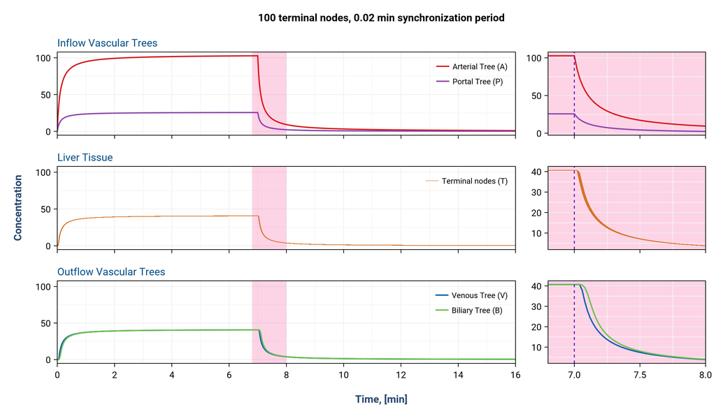

## Simulation · 10 000 terminal nodes

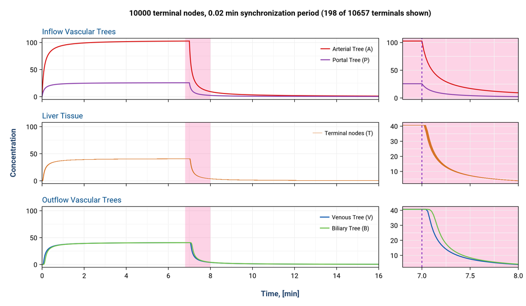

## Simulation · 100 000 terminal nodes

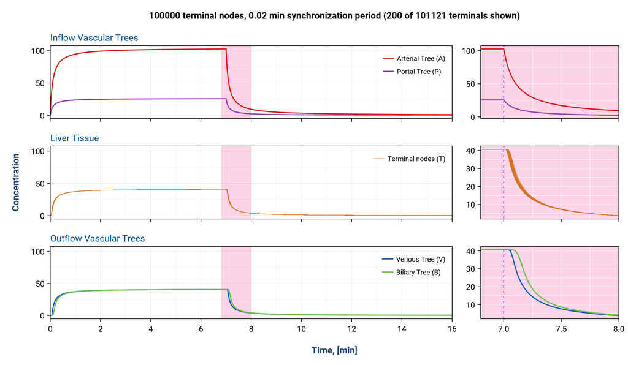

## Simulation · 1 000 000 terminal nodes

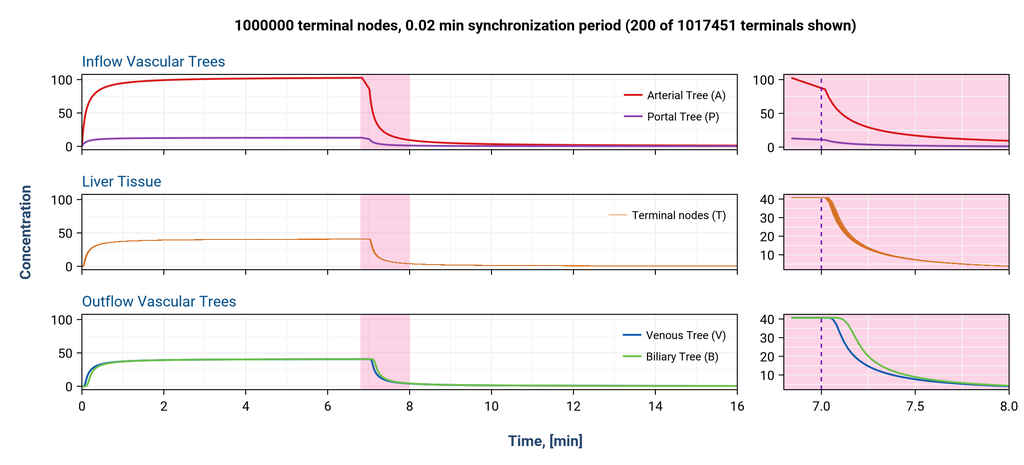

# Code and performance

## Software design

```
src/
├── VascularTrees.jl     # main module
├── common/              # paths, definitions,
│                        # options, table utils, logging
├── trees_processing/    # step 1
│   ├── trees/           #   individual trees
│   └── terminal_nodes/  #   matching (Hungarian,
│                        #   auction)
├── models/              # ODEs, Jacobians, dose
├── simulation/          # step 2
│   ├── setup/           #   parameters, problems
│   ├── solver/          #   time loop, coupling
│   └── results/         #   output, benchmarking
└── visualization/       # step 3: VTKHDF
scripts/                 # one script per step,
                         # main(; options...)
test/                    # whole workflow + Aqua.jl
```

```julia
run_simulations(
    tree_info,
    SimulationOptions(tspan = (0.0, 16.0), steps = 800,
                      save_simulations = true,
                      benchmark = false),
    SolverOptions(solver = CVODE_BDF(linear_solver = :KLU)),
    (dense = false, save_everystep = false),
    1.0,                 # flow scaling factor
    BenchmarkOptions(),
)
```

- every step = one script with one `main(; options...)`
- all settings in **option structs**, checked when they are built
- sysimage built from `scripts/precompile_project.jl` for a fast start-up
- tests run the whole workflow on the smallest tree

## Benchmark

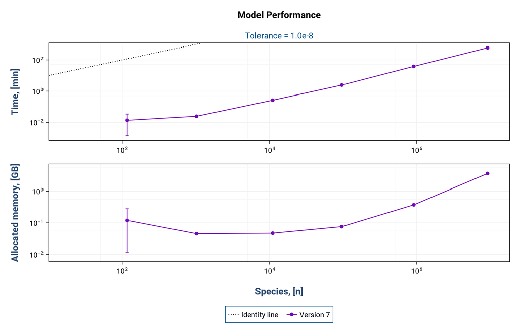

## What should be done next

- switch for the Jacobian: calculate it or not
- optimise the VTKHDF writer — it currently crashes for $10^6$ terminal nodes
- process the trees **with** matching of the closest terminal nodes:
  - `HungarianAssignment()` once as the **gold standard**
  - check the other algorithm (`AuctionAssignment()`) against it
- run the simulations on the trees with matched terminal nodes